# GIS With R: Pre-Workshop Tasks

# Welcome

This document contains all information related to the 2019 SDP GIS With R Workshop in Atlanta, GA (February 7, 2019). Please refer to this document to find all the information you’ll need to get set up and get the most out of this workshop, including software, R packages, and additional resources.

## Instructors

Roland Richard, Gwinnett County Public Schools

Jared Knowles, Civilytics Consulting, LLC

## What do I need to do before the workshop?

You will need to follow these setup instructions:

1. Install/upgrade software
2. Install R packages
3. Set Census API key
4. Create an example map with the tmap package

## 1. **Install or Upgrade Software**

In this workshop, we will use R and [RStudio](https://www.rstudio.com/products/rstudio/). RStudio is highly recommended, because it makes it easier for most users to work with R Markdown.

### Install R

- A [recent version of R](https://cran.rstudio.com/) (>= 3.5.1 “Feather Spray”) is recommended. You can check your version from the R Console:

```r
R.version.string
```

```
## [1] "R version 3.5.1 (2018-07-02)"
```

#### Install RStudio

- [RStudio](https://www.rstudio.com/products/rstudio/download/#download) (>= 1.1.463) is recommended.

#### Upgrading your system

For more help installing or upgrading R and RStudio, please read through these links:

1. [Maintaining R from **What They Forgot to Teach You About R**](https://whattheyforgot.org/maintaining-r.html)
   - See [“How to transfer your library when updating R”](https://whattheyforgot.org/maintaining-r.html#how-to-transfer-your-library-when-updating-r)

## 2. **Install R packages**

For this workshop, you’ll need to install several R packages. See below for a guide to installing the packages we will use. Run this code from your R console to install all of the necessary packages:

```r
pkgs_from_cran <- c("sf", "tmap", "tidyverse", "tidycensus",
                    "leaflet", "mapview","shiny", "ggplot2",
                    "spData", "tigris", "remotes")
```

```r
install.packages(pkgs_from_cran, dependencies = TRUE)
```

### Check all package installs

```r
rlang::is_installed(c(pkgs_from_cran))
```

## 3. **Set Census API key**

To work with census data in the **tidycensus** package, you should load the package along with the **tidyverse** package, and set your Census API key. An API key can be obtained from http://api.census.gov/data/key_signup.html. Follow the code below to set your API key.

```r
library(tidycensus)
library(tidyverse)

census_api_key("YOUR API KEY GOES HERE", install = TRUE)
```

## 4. **Create Example Maps**

### Example tmap

A `tmap` is short for a `thematic map` - a map that is showing spatial data along some theme.

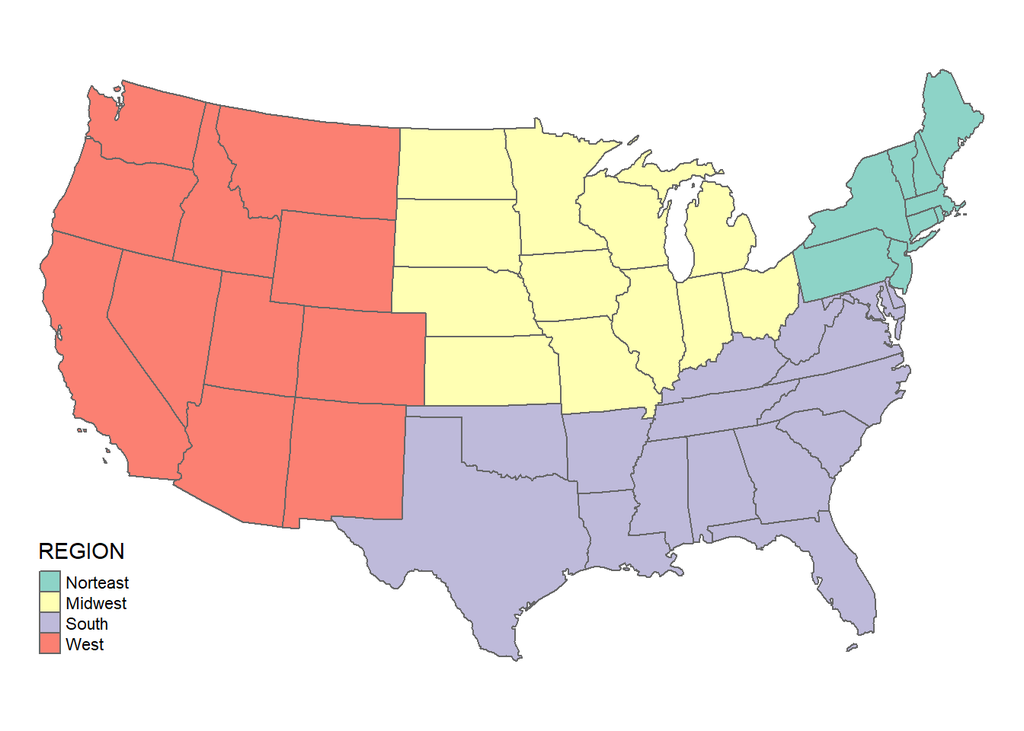

### Example Tigris File Map

You can gain more control over how to make your maps by using shapefiles and `ggplot2` directly.

```r
library(tigris)
ga_districts <- tigris::school_districts("Georgia", type = "unified",
                                         year = 2015)
ga_districts <- sf::st_as_sf(ga_districts)
```

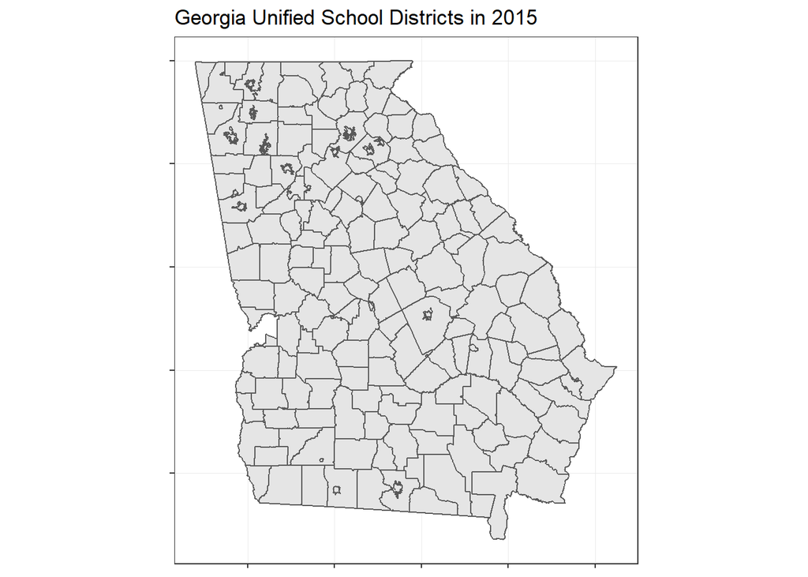

## Next Steps

If you successfully produced the two maps above - you’re ready for the workshop.

At the workshop we’ll cover how to access geospatial data, geospatial data types, and working with geospatial data to make impactful geospatial visualizations of your data.

```r
# KEEP THIS AT THE END OF THE DOCUMENT TO GENERATE A LOCAL bib FILE FOR PKGS
# USED
knitr::write_bib(sub("^package:", "",
                                         grep("package", search(), value=TRUE)))
```

[output not shown]

[output cut: 52 more lines]

[output not shown]